# HW2_McNabb

Catherine McNabb

August 20, 2018

## Problem 1) Flight Info at Austin Bergstrom

First, I’m going to read in the data.

```r
abia = read.csv("ABIA.csv")
```

Then, I am going to create a new column called “total delays”, so we can look at all of the delays together.

```r
abia$totaldelays <- rowSums(abia[,25:29])
attach(abia)
```

Let’s compare total delays by origin and destination to and from Austin Bergstrom.

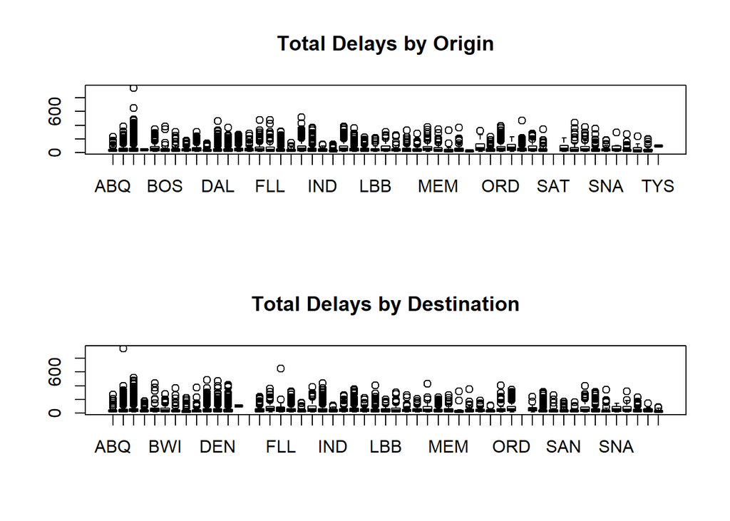

It appears that origin and destination delays are pretty comparable for each airport.

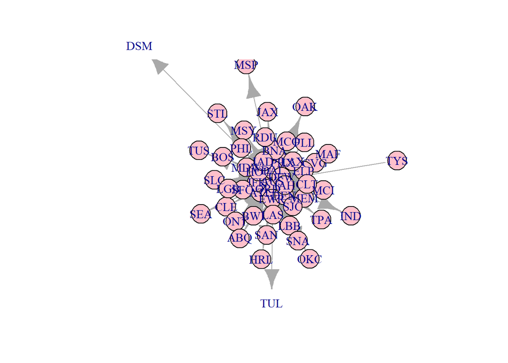

## Problem 2) Predicting Authors

First, I need to load in the data and read it in. I will start with training data.

Then, I need to clean up the names of the documents and authors.

Then, I will clean up the data, so get rid of common words, numbers, weird symbols, etc.

Then do the same with test, including taking care of any words that aren’t in the training data.

Now, I need to do PCA to get the right amount of components.

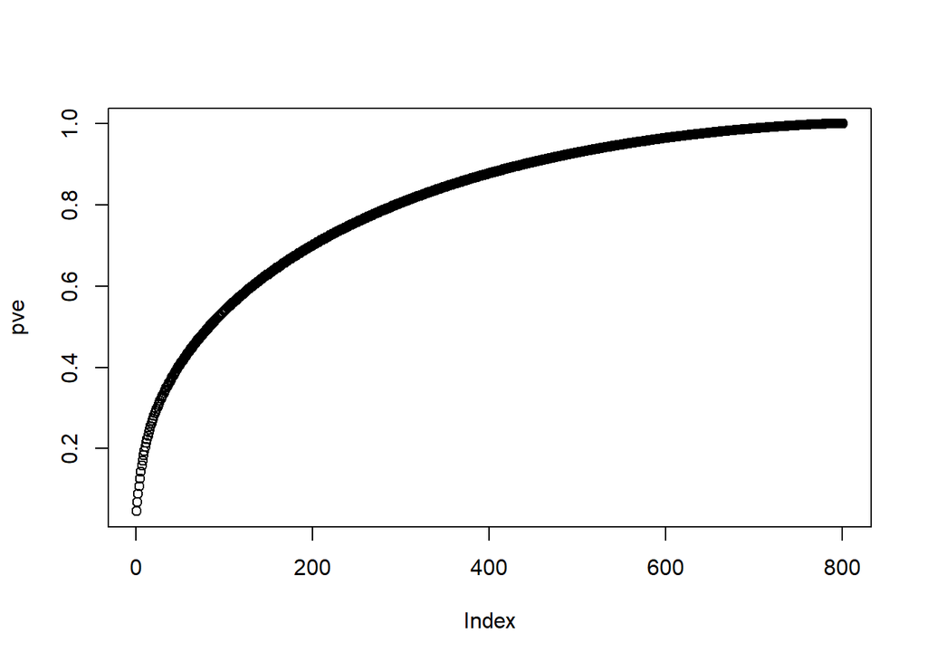

This looks like cutting the data at 100 will do.

Now, we need to turn this into models.

First, random forest:

```
## [1] 0.9768
```

```
## [1] 0.022
```

Unfortunately, seems like we did not predict very well on the test set. We did a LOT better on the training set, which isn’t really helpful.

Now, I’ll try naive bayes.

```
## [1] 0.7736
```

```
## [1] 0.0176
```

Again, very, very poor showing for the the testing set. I probably did something wrong, but this does not bode well for predicting authors.

## Problem 3) Groceries List

First, I’m going to read in the data and correct libraries.

```r
library(tidyverse)
library(arules)  # has a big ecosystem of packages built around it
```

```r
library(arulesViz)
groceries_raw = read.csv("groceries.txt",header=FALSE)
```

Then, I will set the data up to be in the correct format.

```r
x = matrix(0,nrow= nrow(groceries_raw)*4,ncol=2)

counter = 1
x = data.frame(x)
for (i in 1:15296) {
  g = groceries_raw[i,]
  for (j in 1:length(g)) {
    x[counter,1] = i
    x[counter,2] = as.character(g[[j]])
    counter = counter+1
  }
}
```

Now, I will format the data so we can graph using different support and confidence rules.

```r
x$X1 = factor(x$X1)
baskets = split(x=x$X2, f=x$X1)

## Remove duplicates ("de-dupe")
baskets = lapply(baskets, unique)

#make into special arules class
shoptrans = as(baskets, "transactions")

grocerylist = apriori(shoptrans,
                     parameter=list(support=.005, confidence=.1, maxlen=5))
```

```
## Apriori
##
## Parameter specification:
##  confidence minval smax arem  aval originalSupport maxtime support minlen
##         0.1    0.1    1 none FALSE            TRUE       5   0.005      1
##  maxlen target   ext
##       5  rules FALSE
##
## Algorithmic control:
##  filter tree heap memopt load sort verbose
##     0.1 TRUE TRUE  FALSE TRUE    2    TRUE
##
## Absolute minimum support count: 76
##
## set item appearances ...[0 item(s)] done [0.00s].
## set transactions ...[170 item(s), 15296 transaction(s)] done [0.01s].
## sorting and recoding items ... [102 item(s)] done [0.00s].
## creating transaction tree ... done [0.00s].
## checking subsets of size 1 2 3 done [0.00s].
## writing ... [173 rule(s)] done [0.00s].
## creating S4 object  ... done [0.00s].
```

I wanted to look at the results for multiple combinations of support and confidence, so I tried several.

```r
sub1 = subset(grocerylist, subset=confidence > 0.01 & support > 0.005)
sub2 = subset(grocerylist, subset=confidence > 0.05 & support > 0.01)
sub3 = subset(grocerylist, subset=confidence > 0.0075 & support > 0.0045)
```

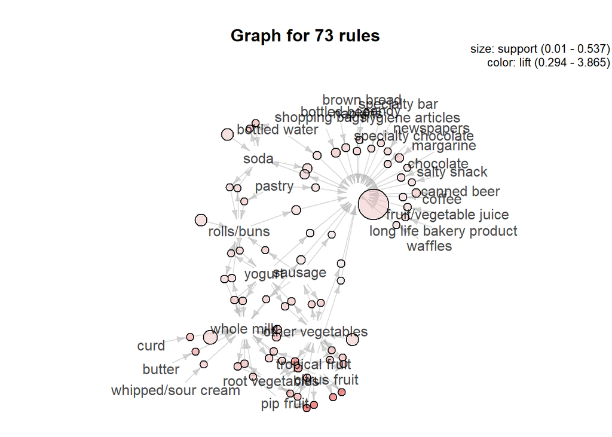

```r
plot(sub2, method='graph')
```